# Merging data streams and counting events

Ross Nygard e.nygard@ufl.edu

2022-10-16 01:07:00

# Introduction

Microbes that decompose plant litter need water. Deserts with infrequent rains have very little of this water, so you would expect decay to happen slowly in these ecosystems. In general, you would be right. But researchers have found that rainfall is a bad predictor of how much decomposition happens in certain deserts. Instead, dew and fog play a key role in wetting plant litter.

Your task here is to figure out at what relative humidity is the leaf sensor more likely to be wet then dry. This assignment uses real data from a coastal system in the Namib Desert to look at how likely the ground is wet given a certain relative humidity. Relative humidity is taken from a standard 2m meteorological station and is in the `data/Far_East_met_stat.csv` file. Precipitation is recorded in `data/Far_East_precip.csv`. And an unusual sensor was used to measure ‘leaf wetness’ in `data/Far_East_LWS.csv`. The sensor measured the conductivity of a surface and calculated a ‘wetness percentage’ based on how much voltage was conducted.

You will need to

1. read in the data and check that the numbers are reasonable
2. merge the data based on observational time
3. Answer the questions:
   - How many wet hours would be under estimated if you only considered rain as events?
   - What is high relative humidity?

Turn in the zip-ed project folder with a compiled html output of this document.

*This is a long assignment! Start early.*

> Your answer to questions should be in a `>` or in a code-chunk comment for ease of grading. Please include this entire template in your response.

## Objectives

1. Load and clean data files in a way that is well documented and reproducible.
2. Support narratives with figures or analytically outputs
3. Identify assumptions needed to support conclusions or interpretation of a data set

# Set things up

To get you started, I’ve suggested a few libraries and associated useful functions that I used for this problem. You should not use any other libraries, but you may use other functions in these libraries.

```r
#Base R: is.finite any mean cumsum length sum max min
library(tidyverse) #select filter summarize mutate read_csv cols everything across if_else group_by ungroup slice
library(tidyr) #separate
library(ggplot2) #ggplot geom_histogram geom_point facet_wrap labs
library(lubridate) #decimal_date ymd_h

#knitr::opts_chunk$set(echo = TRUE, #print out everything in the chunck when you compile the doc
#                      message = FALSE) #don't print out any messages
```

# Loading data

Load data from the three csv files provided in the data folder. Read in the data as characters and figure out which columns contain the following (I suggest you rename the columns to make them easier to work with):

- Time stamps
- Leaf wetness percent
- Relative humidity
- Cumulative rainfall (mm)

Separate the year, month, day, hour (watch for AM/PM vs 24-hour), minute, second from the time stamps. Convert the parts of the time stamp into something that you could merge together (all the years 20XX and hours on a 24hour clock). **Check that the times are well-ordered and fix as needed; document these issues, their fixes and provide checks in the form of summary statistics or figures.** Merge the data into one wide data frame with four columns. Trim the record so that only overlapping times from these observations are in the file data frame (you might want to add a column for a decimal year).

```r
wetness.df <- read_csv('data/Far_East_LWS.csv', # Read the leaf wetness data into a data frame
                       col_types = cols(.default = col_character()))%>%
  # Rename columns to have more memorable names that are easier to type
  rename('Leaf Wetness Percent' = 'Wetness, % (LGR S/N: 2291467, SEN S/N: 10722644)',
         'Time Stamp' = 'Date Time, GMT+00:00') %>%
          # Extract year info from the time stamp column to new year column, then remove year info from time stamp column
  mutate(Year = as.numeric(str_extract(`Time Stamp`, '\\d{4}')),
         `Time Stamp` = str_replace(`Time Stamp`, '\\d{4}-', ''),
         # Extract month info from the time stamp column
         Month = as.numeric(str_extract(`Time Stamp`, '\\d{2}')),
         `Time Stamp` = str_replace(`Time Stamp`, '\\d{2}-', ''),
         # Extract day info from the time stamp column
         Day = as.numeric(str_extract(`Time Stamp`, '\\d{2}')),
         `Time Stamp` = str_replace(`Time Stamp`, '\\d{2}',''),
         # Extract hour info from time stamp column
         hour = as.numeric(str_extract(`Time Stamp`, '\\d{2}')),
         `Time Stamp` = str_replace(`Time Stamp`, 'T\\d{2}:', ''),
         # Extract minute from time stamp column
         minute = as.numeric(str_extract(`Time Stamp`, '\\d{2}')),
         `Time Stamp` = str_replace(`Time Stamp`, '\\d{2}:',''),
         sec = as.numeric(str_extract(`Time Stamp`, '\\d{2}')),
         `Leaf Wetness Percent` = as.numeric(`Leaf Wetness Percent`),
         # Rough decimal month, 30 was chosen to average out the difference in days of the month. This will be consistent in all three dataframes
         decMonth = Month + (Day/30),
         decYear = Year + (decMonth/12)
  )%>%
  # Remove count because R counts rows automatically and removed remaining bit of time stamp column
  select('Leaf Wetness Percent', 'Year', 'Month', 'Day', 'hour', 'minute', 'sec', 'decYear')


precip.df <- read_csv('data/Far_East_precip.csv', # Read the precipitation data into a data frame
                       col_types = cols(.default = col_character()))%>%
  # Give columns names that are memorable and easier to type repeatedly
  rename('Time Stamp' = 'Date Time, GMT+00:00',
         'Cumulative Rainfall (mm)' = 'rain, mm (LGR S/N: 10621789, SEN S/N: 10621789)')%>%
  # Remove logging table from data frame, as it is not relevant to this project
  select('Time Stamp', 'Cumulative Rainfall (mm)')%>%
  # Turn rainfall data to numeric
  mutate(`Cumulative Rainfall (mm)` = as.numeric(`Cumulative Rainfall (mm)`))%>%
  # Remove any NA from the data table, so only values remain
  filter(is.finite(`Cumulative Rainfall (mm)`))%>%
  mutate(Day = str_extract(`Time Stamp`, '../../..'), # Remove date info from Time Stamp to new column. Named 'Day' for convenience
         `Time Stamp` = str_remove(`Time Stamp`, '../../.. '),
         # Remove Month info from temp date column
         Month = as.numeric(str_extract(`Day`, '\\d{2}')),
         `Day` = str_remove(`Day`, '\\d{2}/'),
         # Remove Year info from temp date column
         Year = 2000 + as.numeric( str_extract(`Day`, '\\d{2}$')),
         `Day` = str_remove(`Day`, '/\\d{2}$'),
         `Day` = as.numeric(`Day`),
         # Remove minute info from time stamp
         minute = str_extract(`Time Stamp`,":\\d{2}"),
         `Time Stamp` = str_remove(`Time Stamp`, ':\\d{2}'),
         minute = as.numeric(str_remove(minute, ':')),
         # Remove second info from time stamp
         sec = str_extract(`Time Stamp`, ':\\d{2}'),
         `Time Stamp` = str_remove(`Time Stamp`, ':\\d{2}'),
         sec = as.numeric(str_remove(sec, ':')),
         # Separate pm hours from am, and add 12 to pm to set all hours to 24 hour time scale
         hourPM = str_extract(`Time Stamp`, '\\d{2} PM'),
         hourPM = 12 + as.numeric(str_remove(hourPM, ' PM')),
         hourAM = str_extract(`Time Stamp`, '\\d{2} AM'),
         hourAM = as.numeric(str_remove(hourAM, ' AM'))
  )%>%
  # Combine two different hour columns, then clean and convert to numeric
  unite(col = 'hour', c('hourAM', 'hourPM'))%>%
  mutate(hour = as.numeric(str_remove(hour, '_?NA_?')),
         decMonth = Month + (Day/30),
         decYear = Year + (decMonth/12)
  )%>%
  select('Year', "Month", "Day", "hour", 'minute', 'sec', 'decYear', 'Cumulative Rainfall (mm)')

relHum.df <- read_csv('data/Far_East_met_stat.csv', # Read the meteorological data into a data frame
                        col_types = cols(.default = col_character()))%>%
   rename('Relative Humidity' = 'RH, % (LGR S/N: 10644319, SEN S/N: 10692388)',
          'Time Stamp' = 'Date Time, GMT+00:00')%>%
   # Remove data that is not relevant to this project, such as wind speed
   select('Time Stamp', 'Relative Humidity')%>%
   mutate(`Relative Humidity` = as.numeric(`Relative Humidity`), #Convert relative humidity from character to numeric
         # Remove Hour info from time stamp
         hour = str_extract(`Time Stamp`, '\\d{2}:'),
         `Time Stamp` = str_remove(`Time Stamp`, '\\d{2}:'),
         hour = as.numeric(str_remove(hour, ':')),
         # Remove minute info from time stamp
         minute = str_extract(`Time Stamp`,"\\d{2}:"),
         `Time Stamp` = str_remove(`Time Stamp`, '\\d{2}:'),
         minute = as.numeric(str_remove(minute, ':')),
         # Remove sec info from time stamp
         sec = str_extract(`Time Stamp`, ' \\d{2}'),
         `Time Stamp`= str_remove(`Time Stamp`, ' \\d{2}'),
         sec = as.numeric(str_remove(sec, ' ')),
         # Create two separate versions of a date column to be able to separate the year, month, and day components individually
         yearMonthDay = str_extract(`Time Stamp`, '\\d{4}-\\d{2}-\\d{2}'),
         `Time Stamp` = str_replace(`Time Stamp`, '\\d{4}-\\d{2}-\\d{2}', ''),
         # Extract year info from the column where the year appears first
         year1 = as.numeric(str_extract(yearMonthDay, '\\d{4}')),
         yearMonthDay = str_remove(yearMonthDay, '\\d{4}-'),
         # Extract month info from the column where the year appears first
         month1 = as.numeric(str_extract(yearMonthDay, '\\d{2}')),
         yearMonthDay = str_remove(yearMonthDay, '\\d{2}-'),
         # Extract year info from the column where the year appears at the end, then convert to numeric and add 2000 to get the 4-digit year
         year2 = 2000 + as.numeric(str_extract(`Time Stamp`, '\\d{2}$')),
         `Time Stamp` = str_remove(`Time Stamp`, '-\\d{2}$'),
         # Extract month info from the column where year appears at the end
         month2 = as.numeric(str_extract(`Time Stamp`, '\\d{2}')),
         `Time Stamp` = as.numeric(str_remove(`Time Stamp`, '\\d{2}-'))
  )%>%
  unite(col = 'Year', c('year1', 'year2'))%>% #combine the two methods of extracting the year info into one single column
  unite(col = 'Month', c('month1', 'month2'))%>% # Combine the two separate month columns
  unite (col = 'Day', c('yearMonthDay', 'Time Stamp'))%>% # Combine the yearMonthDay and Time Stamp columns because the only remaining info in them was about the day of the month
  # Remove all extra 'NA' and underscores from the Year, Month, and Day columns, then convert to numeric
  mutate(Year = as.numeric(str_remove(Year, '_?NA_?')),
         Month = as.numeric(str_remove(Month, '_?NA_?')),
         Day = as.numeric(str_remove(Day, '_?NA_?')),
         decMonth = Month + (Day/30),
         decYear = Year + (decMonth/12)
  )%>%
  select('Relative Humidity', 'Year', 'Month', 'Day', 'hour', 'minute', 'sec', 'decYear')

# Combining the three data frames into one data frame on the time based columns
fullData.df <- full_join(precip.df,relHum.df, by = 'decYear')%>%
  full_join(wetness.df, by = 'decYear')%>%
  select('decYear', 'Relative Humidity', 'Cumulative Rainfall (mm)', 'Leaf Wetness Percent')
```

# Harmonize the data

These files came from three separate sensors, you’ll notice that very VERY few of these line up to the second. You will need to line up the data on the hour by grouping by the `year`, `month`, `day`, and `hour`, then summarizing the relative humidity, leaf wetness, and rainfall based on this. Assume that any leaf wetness above 10% is wet, convert the wetness percentage to a logical value using this threshold and report if it was wet during the hour. For this activity it’s less important how much rainfall there was then the fact that there was rainfall during that hour, report the presence of rain instead of the cumulative rainfall.

```r
# Average wetness data by the hour to later join to summarized tables of the other two by the hour
harmoWet.df <- wetness.df%>%
  group_by(Year, Month, Day, hour)%>%
  summarize(`Leaf Wetness Percent` = mean(`Leaf Wetness Percent`), .groups = 'drop')

# Maximum of the cumulative rainfall data by hour (max because the data is cumulative)
harmoPrecip.df <- precip.df%>%
  group_by(Year, Month, Day, hour)%>%
  summarize(`Cumulative Rainfall (mm)` = max(`Cumulative Rainfall (mm)`), .groups = 'drop')

# Average of the relative humidity by hour
harmoRelHum.df <- relHum.df%>%
  group_by(Year, Month, Day, hour)%>%
  summarize(`Relative Humidity` = mean(`Relative Humidity`), .groups = 'drop')

# Combine the three averaged/maxed data tables into one, to compare the data together.
harmoFull.df <- full_join(harmoRelHum.df, harmoPrecip.df, by = c('Year', 'Month', 'Day', 'hour'))%>%
  full_join(harmoWet.df, by = c('Year', 'Month', 'Day', 'hour'))%>%
  # Change the precipitation column to logical as a check whether there was rain that hour
  mutate(`Cumulative Rainfall (mm)` = as.logical(`Cumulative Rainfall (mm)`),
         # 'Is Wet?'column added to check if the leaf is over 10% wet while still keeping the numerical percentage values in the original 'Leaf Wetness Percent' column for later analysis
         `Is Wet?` = if_else(`Leaf Wetness Percent` > 10, TRUE, FALSE)
  )%>%
  replace(is.na(.), FALSE)%>%
  # Rename the precipitation data column as the name is no longer descriptive
  rename('Has Rainfall?' = 'Cumulative Rainfall (mm)')
```

## Cut-off

Assume that the leaf sensor is probably wet during rain events. Create a histogram of the hourly wetness percentage during rain hours. Does this justify the 10% cut off? Why or why not?

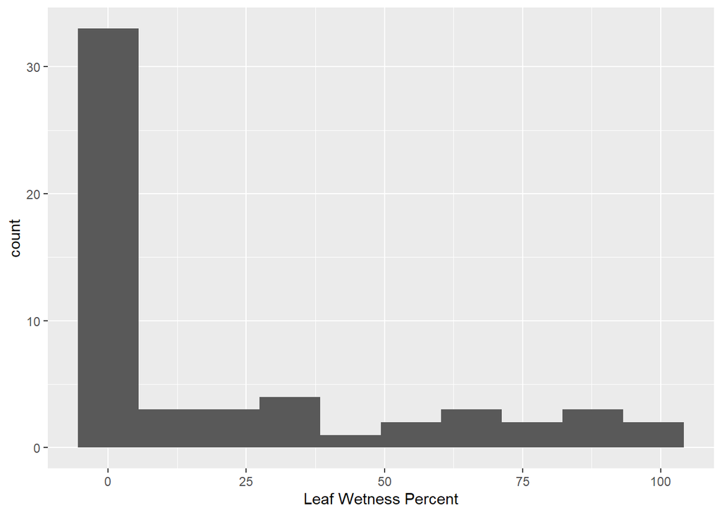

```r
# Create a new dataframe to remove hours without rainfall to make the histogram without overwriting the harmonized data frame for later use
cutOffCheck.df <- harmoFull.df%>%
  select(!'Relative Humidity')%>%
  filter(`Has Rainfall?` == TRUE) # Remove all leaf wetness percent values when there wasn't any rainfall, so that a histogram can be made to determine if the 10% cut off is justified.

ggplot(data = cutOffCheck.df)+
  geom_histogram(mapping = aes(x = `Leaf Wetness Percent`),
                 bins = 10)
```

**Note that I have provided a ‘data/all_data.csv’ file that you may use if you were unable to harmonize your data. You will loose points for using this file but may gain points for part of the assignment below.**

# Plot and summarize

Make a histogram of the relative humidity and create subplots based on the wetness and precipitation status.

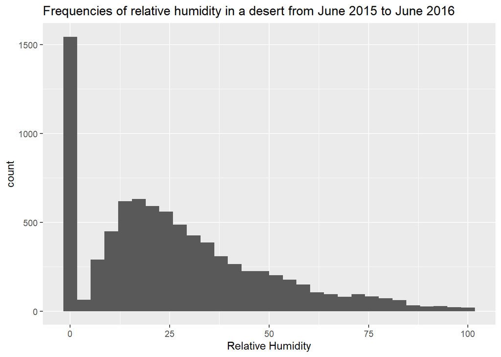

```r
# Modify and pivot the fully harmonized data frame to create the subplots in cases where the leaf was wet or where there was precipitation
histo.df <- harmoFull.df%>%
  select(!"Leaf Wetness Percent")%>% # Remove the leaf wetness percent column, as the data it has isn't relevant to this portion
  pivot_longer(cols = c('Has Rainfall?', 'Is Wet?'))%>%
  filter(value > 0) # Removes cases where there wasn't rainfall and the leaf wasn't wet, so only cases where either or both were true can be analyzed with relative humidity at that hour

# Create a histogram of the relative humidity
ggplot(data = harmoFull.df)+ # Using the harmoFull.df dataframe because it contains the full relative humidity data for each hour
  geom_histogram(mapping = aes(x = `Relative Humidity`))+
  labs(title = 'Frequencies of relative humidity in a desert from June 2015 to June 2016')
```

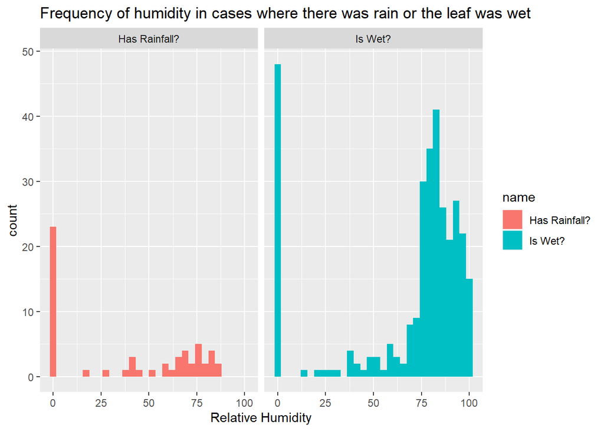

```r
ggplot(data = histo.df)+ # Using histo.df to separate the relative humidity when there was rainfall from the relative humidity when the leaf was over 10% wet
  geom_histogram(mapping = aes(x = `Relative Humidity`, fill = name), # Name will separate cases where the leaf was wet from cases when there was rain. It does not separate the cases where there was both rainfall and the leaf was wet.
                 bins = 30)+ # Suppresses the message about binwidth
  facet_wrap(~name)+ # Separate the two subplots from each other. The two plots have the same y-axis scale for comparison against the two cases.
  labs(title = 'Frequency of humidity in cases where there was rain or the leaf was wet')
```

## Missed hours

If you were to assume that the leaf was only wet during rain events, how many hours in this record would you miss and what fraction of the total wet time is this? (Show your code)

```r
missHour.df <- histo.df%>% # Using histo.df rather than harmoFull.df because it already contains only hours where there was rainfall, the leaf was wet, or both
  pivot_wider(names_from = name, values_from = value)%>%
  replace(is.na(.), FALSE)%>% # Reinserts FALSE where there is NA to use later
  mutate(`Has Rainfall?` = as.numeric(`Has Rainfall?`), # Convert the logical values in 'Has Rainfall?' to 1 or 0 to sum. The same is done to 'Is Wet?'
         `Is Wet?` = as.numeric(`Is Wet?`),
         overlap = `Has Rainfall?` + `Is Wet?`, # Overlap column added to determine how many hours had both rainfall and a wet leaf
         overlap = if_else(overlap == 2, 1, 0)
  )

# Sum the 'Is wet' and 'Has rainfall' columns to determine how many hours were wet and how many were raining
wetHours <- sum(missHour.df['Is Wet?'])
precipHours <- sum(missHour.df['Has Rainfall?'])
overlapHours <- sum(missHour.df['overlap'])

wetHours
```

```
## [1] 311
```

```r
precipHours
```

```
## [1] 56
```

```r
percWet <- (precipHours / wetHours) * 100
percWet
```

```
## [1] 18.00643
```

> Assuming that the leaf is wet only during rain would lead one to believe that the leaf is wet 56 hours over the roughly one year time period, which is only 18% of the hours the leaf spent wet.